# 2.05-Doubly-Linked-Lists

### Table of Complexity Comparison - Array vs Singly Linked List vs Doubly Linked List

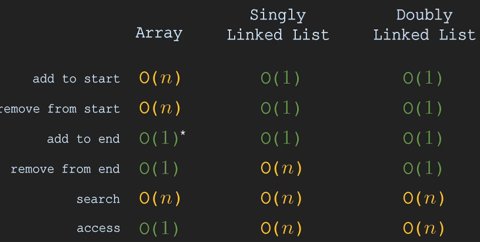

We noticed by looking at this table that the doubly linked list excels at one thing, it has the best possible performance on adding and removing from both ends. It's better than the singly linked list and much better than the regular array. So you might ask yourself, why would you ever want to use the singly linked list if the doubly is overall better?

Well, like always, there are some tradeoffs. Doubly linked lists perform better in more cases, but they also require more memory. And that's because of the nodes it's built with. Each node has to carry one additional pointer. we know how they're stored in memory, more pointers means more space consumed. This can become noticeable for very large linked lists, where a significant amount of memory is allocated for the pointers. On the other hand, in today's day and age, devices generally have enough memory. So again, it's something you need to decide based on the problem you're trying to solve and whether or not memory is an issue for you

We can say that linked lists overcome some limitations of the regular array, and they do that by storing the data in node objects. This allows fast insertion and deletion from the start of the list, and in the case of the doubly linked list from the end as well. In a normal array, those operations would mean shifting all the existing elements to adjust for the new state of the list, and that would impact the entire array. But arrays also have some advantages over the linked lists. Because they use indices, we can immediately access the element at any position just by providing its index. In a linked list we can't do that. We have to navigate through the entire list to reach the desired nodem

### Real-Life Applications of Linked Lists

#### Doubly Linked List (DLL)

- **Web Browsers (Back/Forward Navigation)**
  - Each page visited is a node; allows moving backward or forward easily.
- **Music & Video Players**
  - Playlists allow moving to the next or previous track/video seamlessly.
- **Undo/Redo Functionality**
  - Text editors and design tools use DLLs to move back and forth between states.
- **Photo Galleries**
  - Navigate images forward/backward in a collection.
- **Cache Implementation (LRU Cache)**
  - DLL + HashMap used in Least Recently Used (LRU) cache design.
  - Examples: Browser cache, memory caching in systems.
- **Gaming (Deck of Cards, Board Games)**
  - Representing cards or moves where bidirectional traversal is needed.

#### Comparison Table

| Use Case | Singly Linked List | Doubly Linked List |
| --- | --- | --- |
| Memory management | ✅ | ❌ |
| Stacks/Queues | ✅ | ❌ |
| Browser navigation | ❌ | ✅ |
| Music/Video playlists | ❌ | ✅ |
| Undo/Redo in editors | ❌ | ✅ |
| Sparse matrices | ✅ | ❌ |
| LRU Cache | ❌ | ✅ |

#### Key Takeaways

- **SLL** → lightweight, forward-only traversal, good for queues, stacks, memory blocks.
- **DLL** → heavier (extra pointer per node), but supports bidirectional traversal and faster deletions.
- Choice depends on whether you need **simplicity & memory efficiency** (SLL) or **flexibility & bidirectional navigation** (DLL).